**剩余价值模拟器**

**产品说明书**

# 概述

## 软件名称

剩余价值模拟器

## 软件用途

本软件是一款回合制经济模拟游戏，旨在通过对资本主义经济运行机制进行简化的数字仿真，帮助玩家理解劳动力、商品、债权、股权、地权等经济要素在市场中的交易与流通逻辑。软件适用于对经济学、策略模拟感兴趣的普通用户。

## 核心功能概述

软件的核心玩法围绕“经济单位”与“市场系统”展开。每一回合中，所有经济单位（如企业、家庭、银行等）均会按照自身预设及玩家干预，在各类市场（劳动力市场、商品市场、金融市场、土地市场等）中执行特定的经济操作。主要功能模块包括：

### 多经济单位模拟

软件内置多个具有独立经济行为的经济单位，每个单位拥有独立的资产负债表、收支记录、物资清单及操作预设。系统自动模拟各单位在每回合中的生产、消费、投资、借贷、雇佣、买卖等行为。

### 多层次市场系统

支持劳动力、商品、债权、股权、地权等多类市场的实时交易与流通。不同市场遵循各自的定价机制，市场交易结果会动态影响各单位的经济状况。

### 信息面板查看

玩家可以随时查阅任意经济单位的以下详细信息：

#### 资产负债表

资产与负债的明细及总计

#### 收支情况

每回合的收入来源与支出项目

#### 操作预设

单位在当前及未来回合中计划执行的经济操作指令集

#### 物资清单

各类商品、原材料、的库存数量及价值

#### 基本信息

单位名称、类型及类型对应的专属信息

### 商品生产规则

游戏中有四种商品类型：矿产、设备、基础设施、消费品。

生产矿产需要消耗采矿权、人类劳动力；生产设备、基础设施、消费品均分别需要消耗不同数量的矿产和人类劳动力；每使用一点劳动力需要消耗一点设备库存；用人单位每雇佣一点劳动力需要自身拥有对应数量的基础设施库存

### 玩家干预机制

在每个新回合开始前，玩家可以**修改某些经济单位的预设行为**（例如调整企业生产数量、设定政府税率、设定央行基准利率、设定股票买卖价值量等），从而对游戏进程施加有限但策略性的影响。干预结果将随回合推进逐步反映在各项经济指标中。

## 运行环境

### 操作系统

Windows10/11

### 运行方式

单机本地运行

### 开发语言/框架

使用godot游戏开发引擎及引擎内置脚本语言gdscript开发

# 功能描述

## 菜单界面

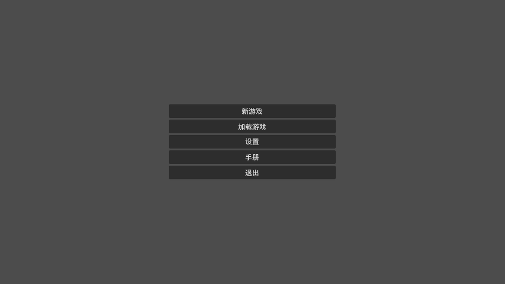

进入游戏后首先是菜单界面，界面中按钮的功能如下

### 新游戏

点击进入创建游戏界面

### 加载游戏

点击进入加载历史存档界面

### 设置

点击进入游戏设置界面

### 手册

点击打开手册所在网页

[剩余价值模拟器v1.0产品说明书](https://zhengyuwz.github.io/Surplus-Value-Simulator-manual/zh_manual/index.html)

### 退出

点击退出程序

## 游戏创建界面

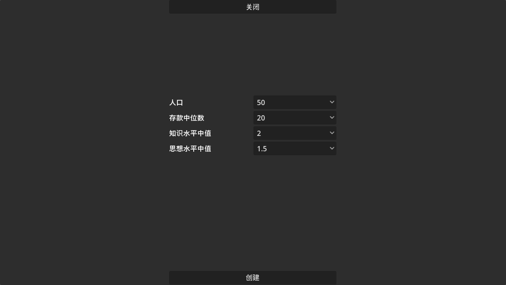

在此界面设定游戏的各项初始参数，点击创建，进入游戏

## 游戏存档加载界面

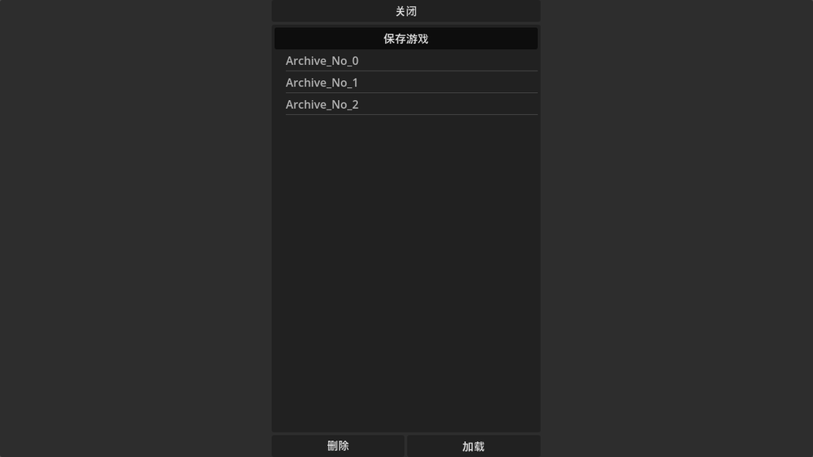

单击选中存档，点击下方的删除或加载按钮可以删除或加载历史存档

## 游戏设置界面

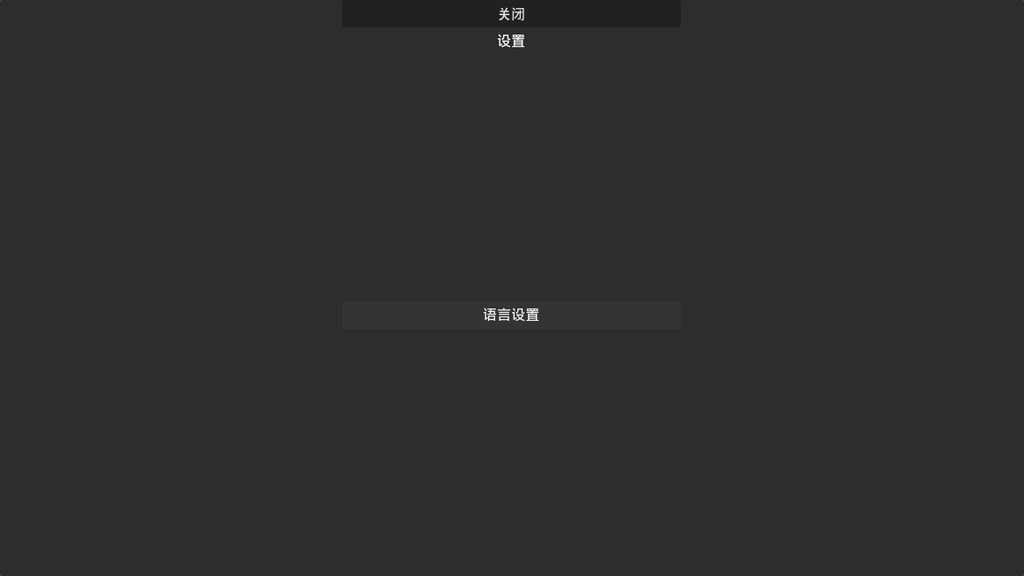

点击语言设置进入语言设置界面可以设置游戏界面的语言类型，目前支持中文和英文

## 游戏主界面

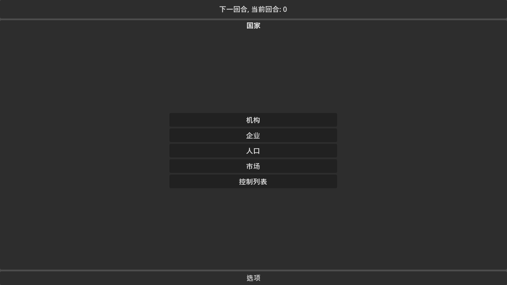

### 回合按钮

点击进入下一回合

### 机构

点击进入机构列表

### 企业

点击进入企业列表

### 人口

点击进入人口列表

### 市场

点击进入市场列表

### 控制列表

点击进入控制列表

## 机构列表

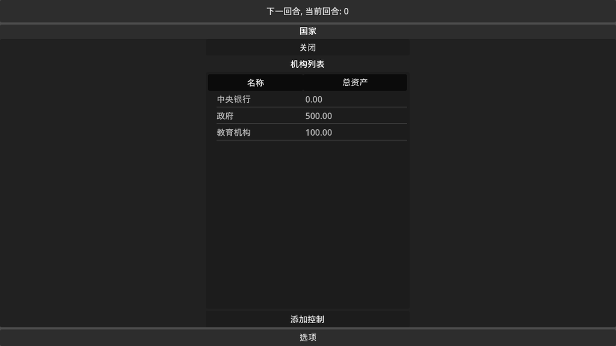

此处列出机构类经济单位包括央行、政府、教育，单机表格标题可按表项内容排序，双击表项可进入经济单位信息面板，单击选中并点击下方“添加控制”按钮，可将被选中单位设备当前控制单位，进而控制其增加或删除经济操作预设

## 企业列表

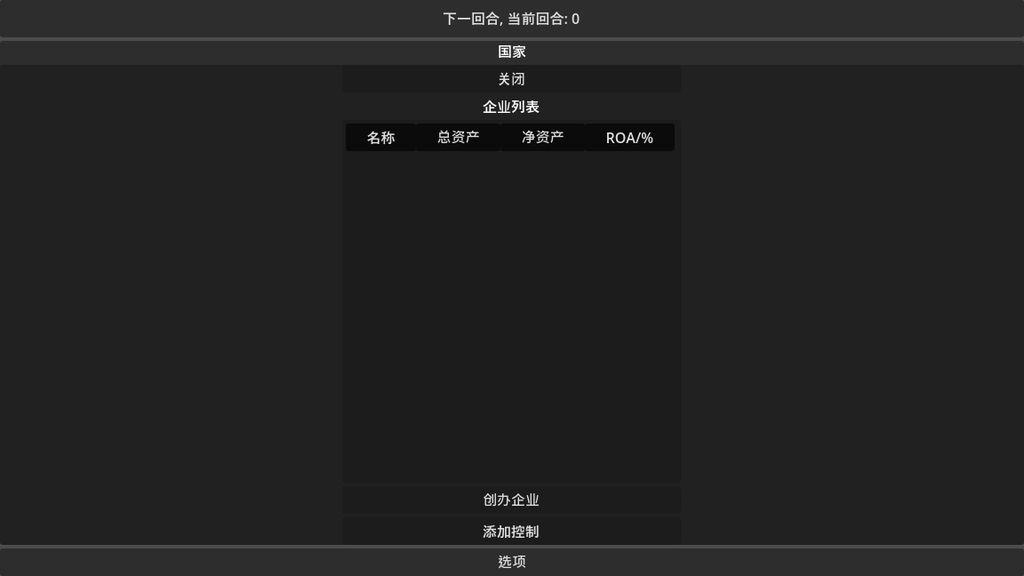

该界面为企业列表，企业类型包含公司和商业银行，当设定了当前控制对象时，点击下方创办企业按钮进入创办企业界面。

## 人口列表

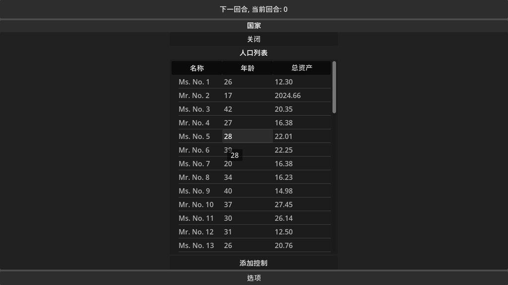

该界面为人口列表

## 经济单位信息界面

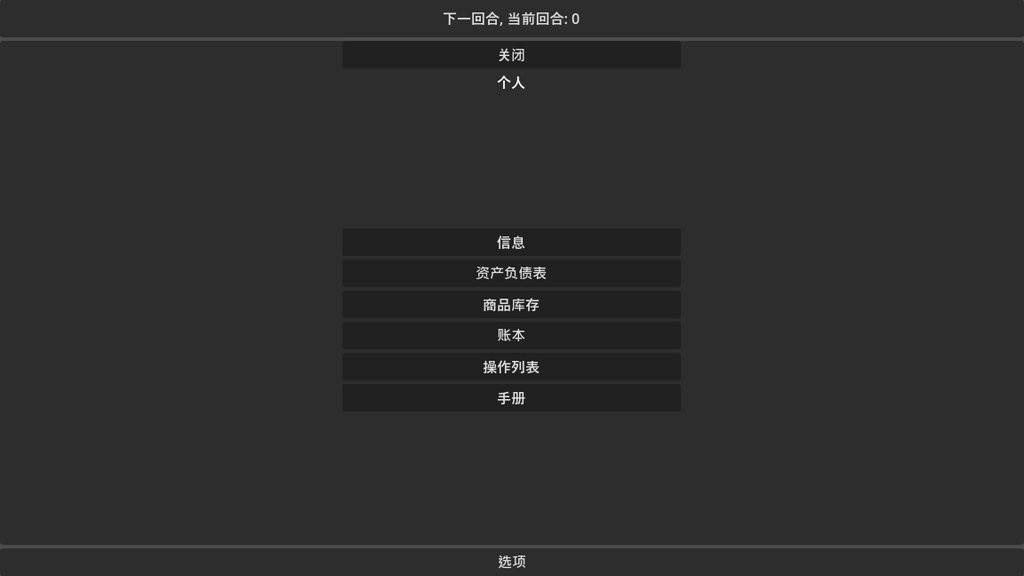

此界面包含经济单位的所有信息，包括单位基本信息、资产负债表、商品库存、收支账本、操作列表、简要的说明手册

### 经济单位基本信息界面

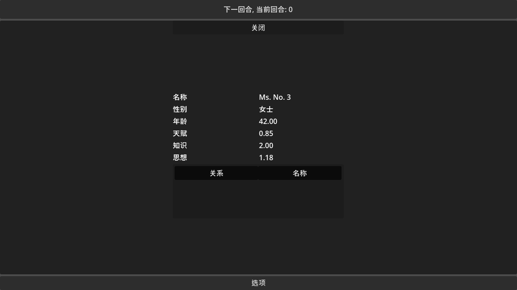

此界面显示不同类型的经济单位的基础信息，不同地经济单位拥有特定的基础信息

### 经济单位资产负债表

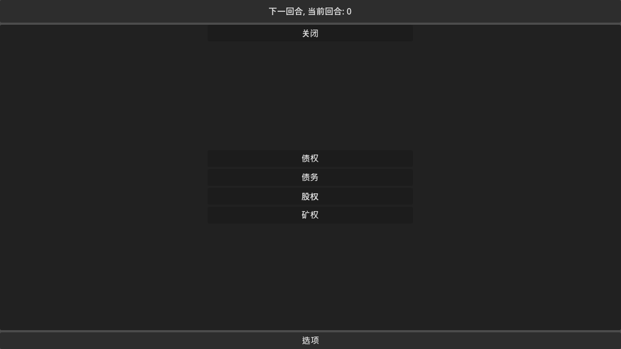

此界面包含单位的资产和负债信息，包括债权列表、债务列表、股权列表、采矿权列表，双击列表项可跳转至债务人、债权人、股份持有者、被持有对象、土地所有者所在单位列表中的位置

### 经济单位商品库存界面

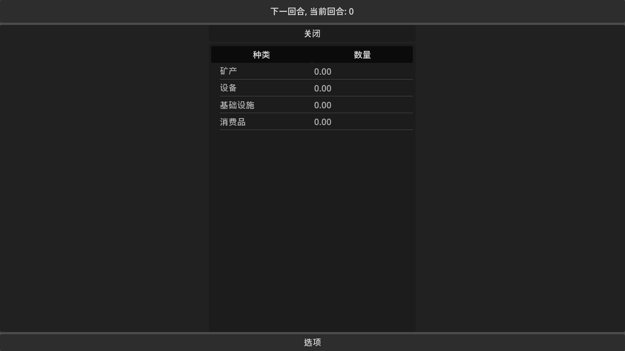

### 经济单位收支界面

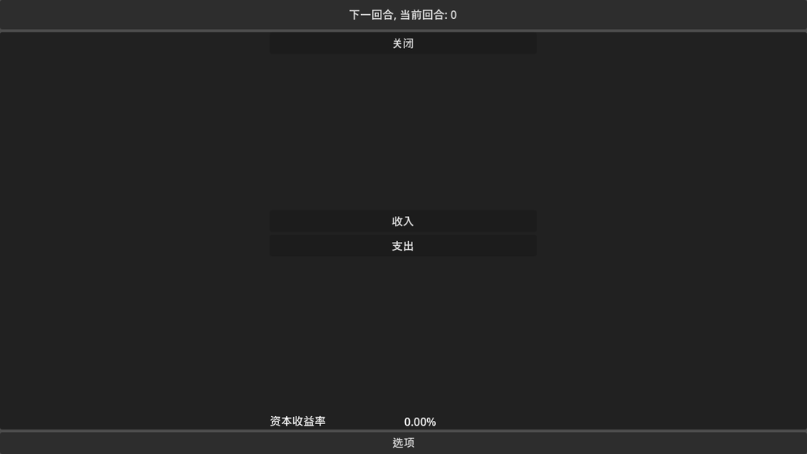

此界面显示经济单位在上一回合的经济活动结束后的收支数据，包括收支的类型和金额

### 经济单位操作预设界面

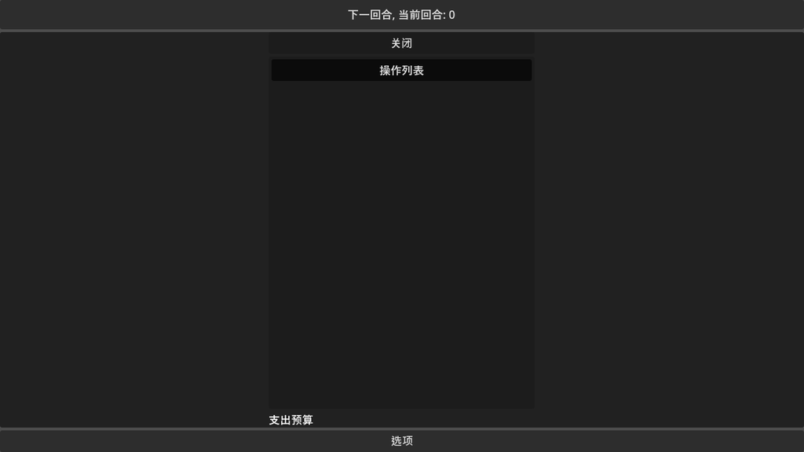

此界面显示经济单位在玩家点击下一回合后执行的操作

### 经济但单位手册界面

此界面显示单位的简单介绍

## 市场列表

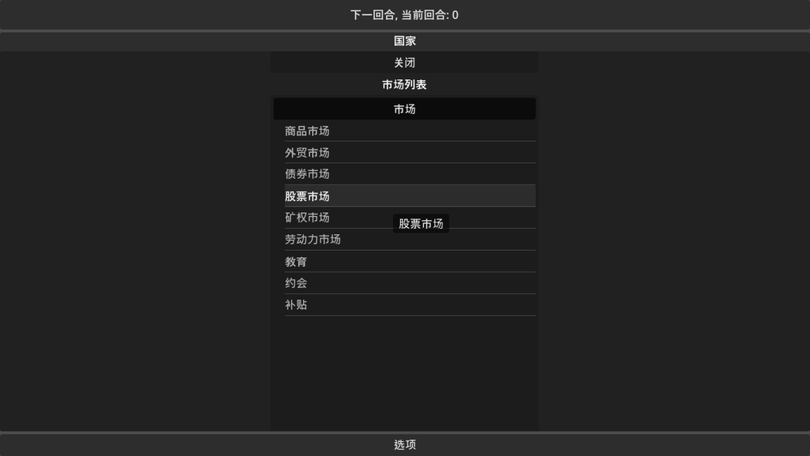

该界面为市场列表

### 商品市场

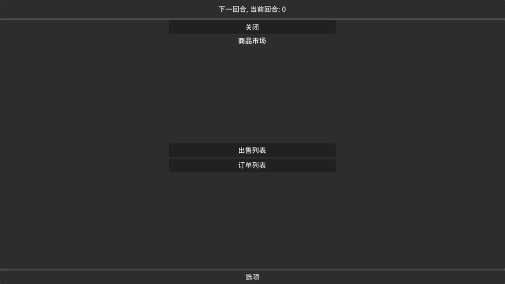

商品市场界面，经济单位可在商品市场出售自己持有的商品、购买其他经济单位持有的在市场上出售的商品

#### 商品市场出售列表

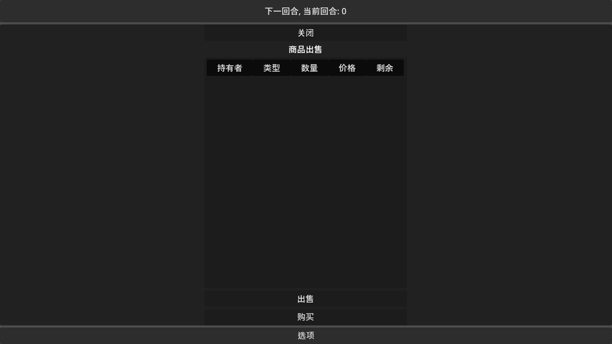

列表中列出了所有的正在出售商品的商品持有者；双击表项可跳转至持有者所在单位列表；如果设置了当前控制单位，点击出售进入商品出售界面出售自己所拥有的商品；选中出售列表中的某一项，再点击购买，进入商品购买界面，从选定的持有者处购买特定的商品

#### 商品市场订单列表

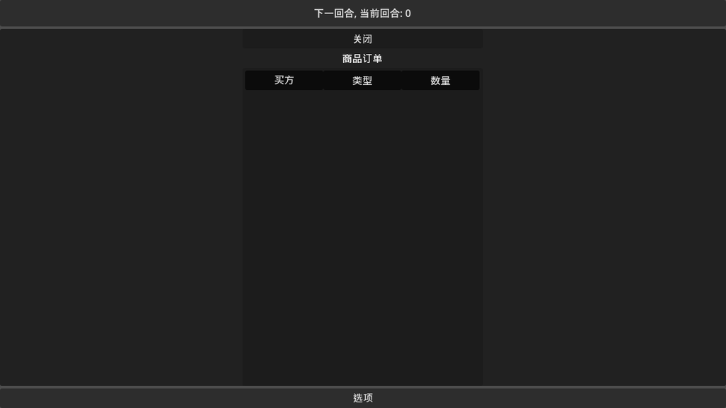

该列表列出所有买方的购买订单，双击表项可跳转至买房所在单位列表；表项内容为买方、商品类型、购买数量

### 外贸市场

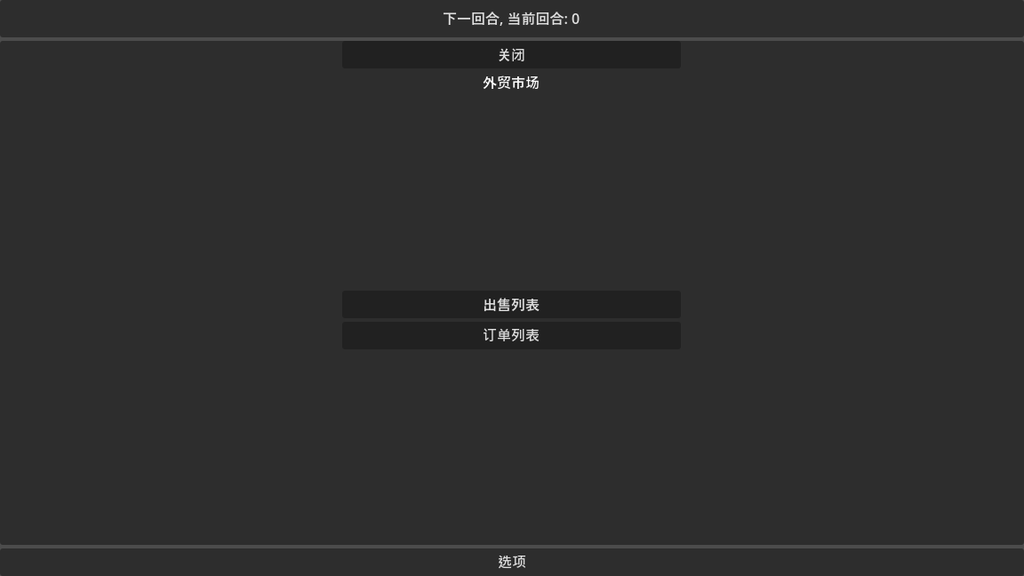

该界面为外贸市场，与前述类似，该市场包含所有的出口订单和进口订单，出口订单的买方和进口订单地卖方是抽象的外部经济单位，不在游戏内显示

### 债券交易市场

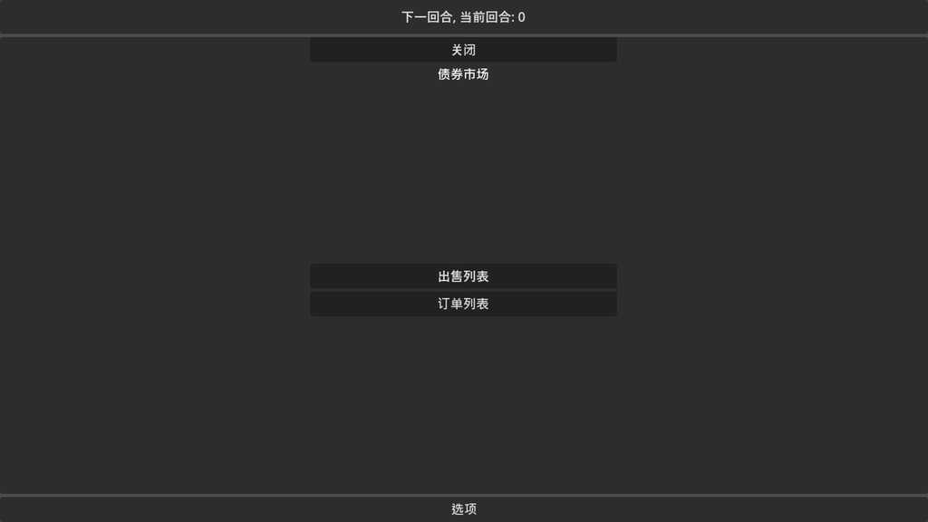

经济单位在该市场内可以作为卖方出售自己持有的债权，也可以作为买方购买另一个经济单位持有的债权

### 股票交易市场

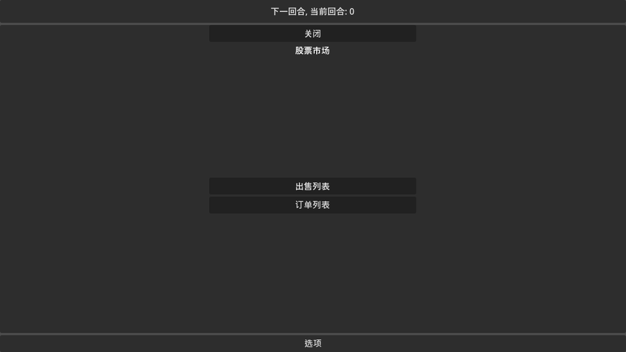

在该市场中，居民经济单位可以出售自己手中的股权，或购买另一个经济单位持有的股权；企业经济单位可以出售自身股权换取投资，股份的价值由股权比例和企业的市值决定

### 采矿权交易市场

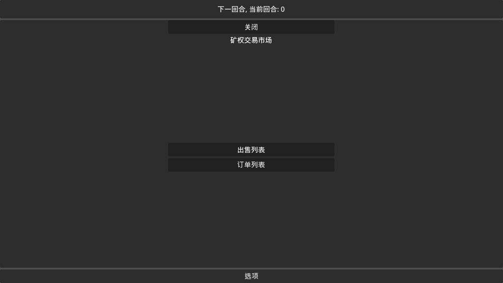

在该市场中经济单位可以出售自己持有的矿权、购买另一个单位持有的矿权，其价格由矿权数量、成品矿石价格、利息率、社会平均利润率决定

### 劳动力市场

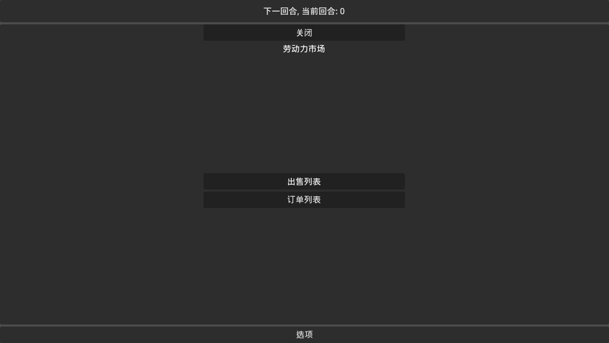

作为个体居民的经济单位可以在此市场中出售自己的劳动力，其价值为劳动力的量，其价格与消费品的价格相关；作为用人单位的企业可以在该市场中购买劳动力

### 教育资源市场

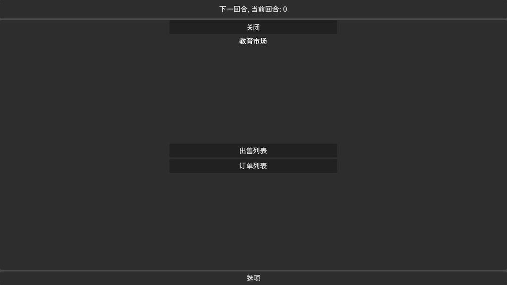

教育机构在该市场出售教育资源，其价值等于教育资源的量，个体居民在该市场中购买教育资源

### 相亲市场

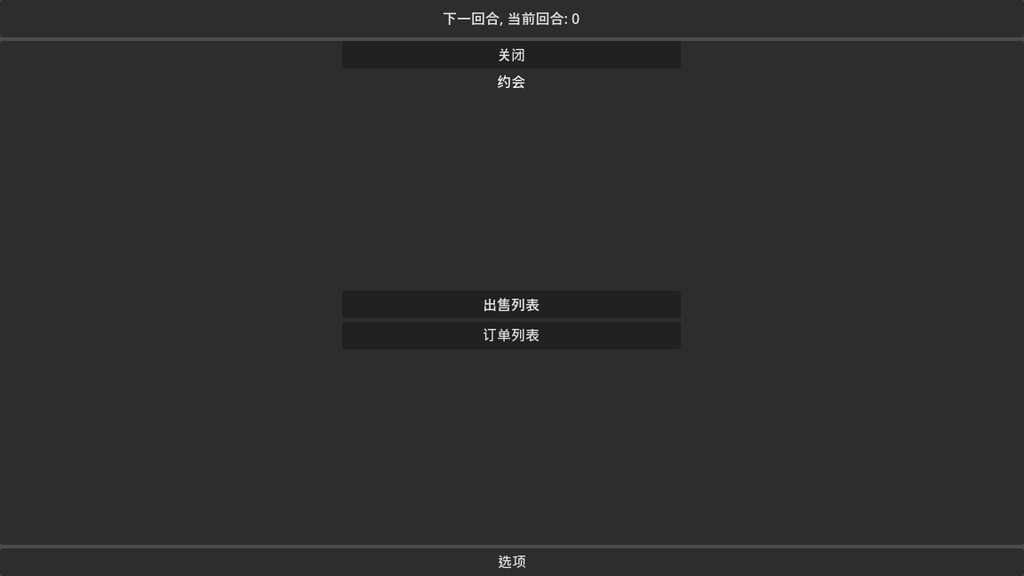

个体居民可以在市场接受约会邀请或者发出约会邀请

### 补贴市场

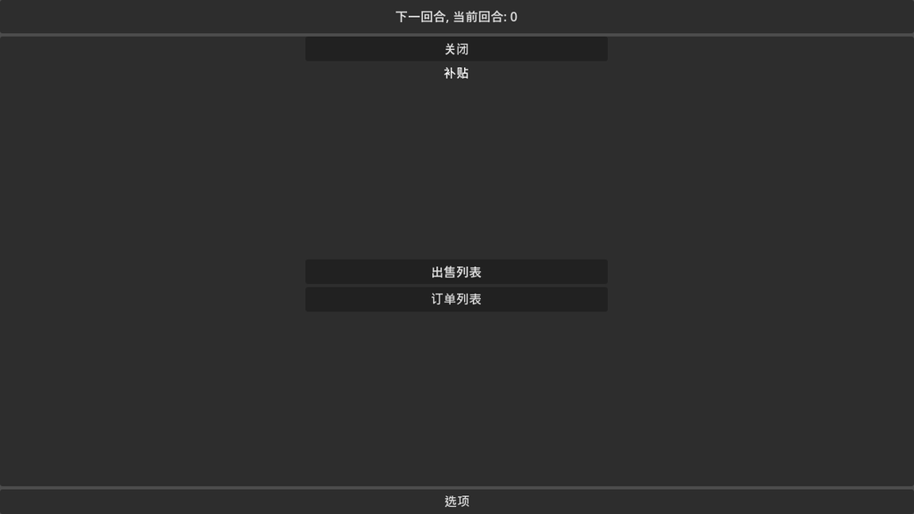

居民或者企业可以根据自己的经济需求在该市场提交补贴申请，政府可以选择为哪些单位提供补贴